# HOMEWORK 2 (Intro to ML - Demo 2 / Data Pre-Processing & Regression)

## Questions/Tasks to be done

3. Select one of the imputed data sets from b. Keep the data splitting with 70% / 30%.
   - why did you select this data set?
   - play with the predictors and the response parameters and try to find a better model (use diverse transformation, multiplication of predictions, etc.)

### Missing values and PMM (predictive mean matching)

Now we are using PMM to treat our missing value problem

```r
imputed_data_pmm <- mice(dataset,m=5,maxit=50,method='pmm', seed= 500,printFlag=F)
```

```r
par(mfrow=c(2,3))
boxplot(complete(imputed_data_pmm,1))
boxplot(complete(imputed_data_pmm,2))
```

```r
boxplot(complete(imputed_data_pmm,3))
boxplot(complete(imputed_data_pmm,4))
```

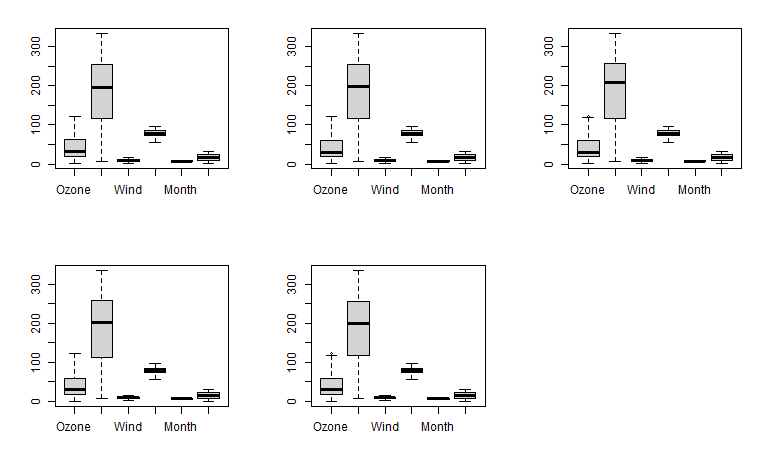

```r
boxplot(complete(imputed_data_pmm,5))
```

In PMM number 3 and 5 we have some outliers in the boxplot so we dont take these. Number 4 has a slightly lower median than our original boxplot. So this time i continue with PMM number 1 and also, the data are good presented in the hull in the pairs/scatter plot below.

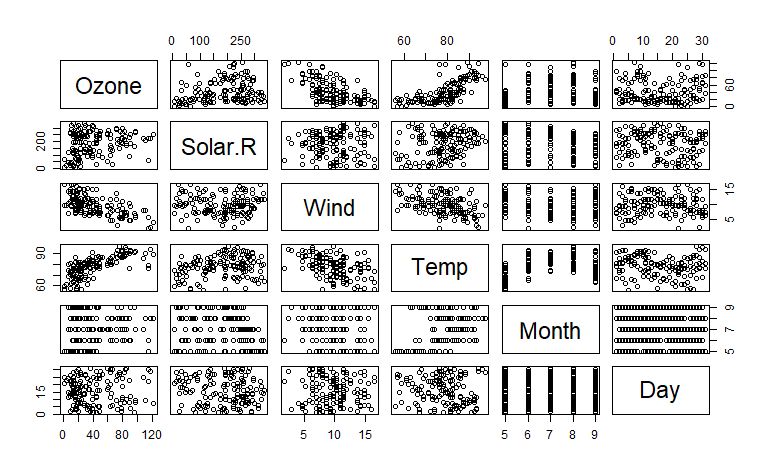

```r
pairs(complete(imputed_data_pmm,1))
```

```
 /\     /\
{  `---'  }
{  O   O  }
==>  V <==  No need for mice. This data set is completely observed.
 \  \|/  /
  `-----'

    Ozone Solar.R Wind Temp Month Day
148     1       1    1    1     1   1 0
        0       0    0    0     0   0 0
```

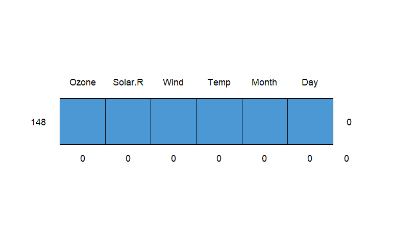

```r
md.pattern((complete(imputed_data_pmm,1)))
```

Now we have 148 values with which we will continue.

# Normalization

We now use median and IQR normalization. We also will try later not to normalize and see how this alters the model

```r
IQR <- apply(complete(imputed_data_pmm,1)[,2:4],2, IQR, na.rm=T)
med <- apply(complete(imputed_data_pmm,1)[,2:4],2, median, na.rm=T)

data_normalized <- data.frame("Ozone"=complete(imputed_data_pmm,1)$Ozone,
                              scale(complete(imputed_data_pmm,1)[,2:4], center=med, scale = IQR), complete(imputed_data_pmm,1)[,5:6])
```

# Split the data: create a training and a test data set

```r
# Create a list of 70% of the rows in the original dataset we can use for training
train_index<-createDataPartition(data_normalized$Ozone, p =0.70, list = FALSE)

# Select 30% of the data for testing
testing<-data_normalized[-train_index, ]

# Use the remaining 70% of data to train and validate the models
training <-data_normalized[train_index, ]
```

With the code above we again did a 70:30 split for training and testing the model.

# Choose & evaluate ML models

```r
# Linear Regression model
set.seed(7)
fit.lm <- train(Ozone~., data=training, method="lm", metric="Rsquared")

fit.lm
```

```
Linear Regression

106 samples
  5 predictor

No pre-processing
Resampling: Bootstrapped (25 reps)
Summary of sample sizes: 106, 106, 106, 106, 106, 106, ...
Resampling results:

  RMSE      Rsquared   MAE
  18.90313  0.6103876  14.8832

Tuning parameter 'intercept' was held constant at a value of TRUE
```

Here we see a not so optimal Rsquared coeff. of 0.61, slightly better than with the PMM number 2 imputation.

```r
summary(fit.lm)
```

```
Call:
lm(formula = .outcome ~ ., data = dat)

Residuals:
    Min      1Q  Median      3Q     Max
-39.141 -10.782  -1.991  10.683  49.303

Coefficients:
            Estimate Std. Error t value Pr(>|t|)
(Intercept)  57.8173    10.1246   5.711 1.16e-07 ***
Solar.R       4.1039     2.7965   1.468   0.1454
Wind        -13.4436     2.3684  -5.676 1.35e-07 ***
Temp         21.8252     2.8101   7.767 7.19e-12 ***
Month        -2.5503     1.3633  -1.871   0.0643 .
Day           0.2939     0.1947   1.510   0.1343
---
Signif. codes:  0 ‘***’ 0.001 ‘**’ 0.01 ‘*’ 0.05 ‘.’ 0.1 ‘ ’ 1

Residual standard error: 17.54 on 100 degrees of freedom
Multiple R-squared:  0.6552,    Adjusted R-squared:  0.638
F-statistic: 38.01 on 5 and 100 DF,  p-value: < 2.2e-16
```

Only wind and temp are sign. for the model, this is also seen in the plot below.

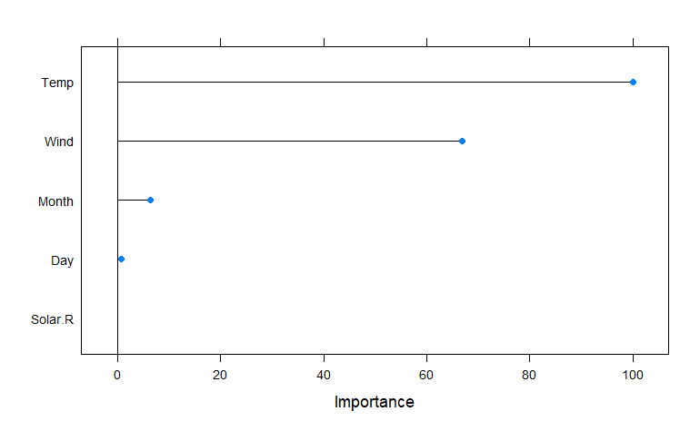

```r
plot(varImp(fit.lm))
```

So we take these variables for further improvement.

```r
fit.lm1 <- train(Ozone~Wind+Temp, data=training, method="lm", metric="Rsquared")

summary(fit.lm1)
```

```
Call:
lm(formula = .outcome ~ ., data = dat)

Residuals:
    Min      1Q  Median      3Q     Max
-40.929 -10.008  -2.152  12.316  49.487

Coefficients:
            Estimate Std. Error t value Pr(>|t|)
(Intercept)   44.296      1.761  25.160  < 2e-16 ***
Wind         -13.474      2.399  -5.616 1.67e-07 ***
Temp          20.297      2.463   8.242 5.74e-13 ***
---
Signif. codes:  0 ‘***’ 0.001 ‘**’ 0.01 ‘*’ 0.05 ‘.’ 0.1 ‘ ’ 1

Residual standard error: 17.99 on 103 degrees of freedom
Multiple R-squared:  0.6263,    Adjusted R-squared:  0.619
F-statistic: 86.31 on 2 and 103 DF,  p-value: < 2.2e-16
```

### Check the prediction Quality

Make predictions on unseen data

```r
predictions<-predict(fit.lm1, testing)
```

Check the distribution of the residuals

```r
# density plot of residuals
residuals <- testing$Ozone - predictions
```

Now we want to see how the model behaves with our testing data. And it shows no normal distribution. More a skewed distribution.

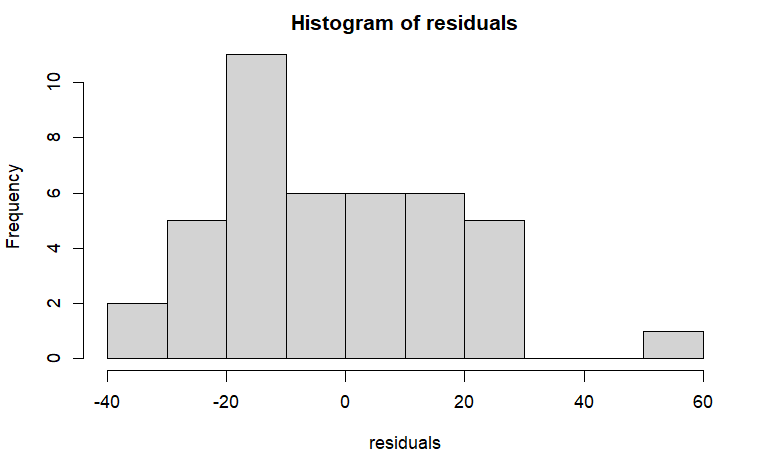

```r
hist(residuals)
```

Coefficient of determination

```r
SSE <- sum(residuals^2)
SST <- sum((testing$Ozone-mean(testing$Ozone))^2)
Rsq <-1-SSE/SST
Rsq
```

```
[1] 0.5690257
```

After we make a prediction test with our 30% testing dataset we see that the R-squared coefficient with 56% of the variable variation around its mean is slightly higher than with the PMM 2 data with 54%.

# New Approach without normalization.

# Split the data: create a training and a test data set

```r
# Create a list of 70% of the rows in the original dataset we can use for training
train_index<-createDataPartition(complete(imputed_data_pmm,1)$Ozone, p =0.70, list = FALSE)

# Select 30% of the data for testing
testing<-complete(imputed_data_pmm,1)[-train_index, ]

# Use the remaining 70% of data to train and validate the models
training <-complete(imputed_data_pmm,1)[train_index, ]
```

With the code above we again did a 70:30 split but with the not normalized dataset for training and testing the model.

# Choose & evaluate ML models

```r
# Linear Regression model
set.seed(7)
fit.lm <- train(Ozone~., data=training, method="lm", metric="Rsquared")

fit.lm
```

```
Linear Regression

106 samples
  5 predictor

No pre-processing
Resampling: Bootstrapped (25 reps)
Summary of sample sizes: 106, 106, 106, 106, 106, 106, ...
Resampling results:

  RMSE      Rsquared   MAE
  16.97751  0.6372965  13.23145

Tuning parameter 'intercept' was held constant at a value of TRUE
```

Here we see a slightly better Rsquared coeff. of 0.64, than with the normalized data

```r
summary(fit.lm)
```

```
Call:
lm(formula = .outcome ~ ., data = dat)

Residuals:
    Min      1Q  Median      3Q     Max
-38.449 -11.562   0.039   9.981  47.441

Coefficients:
             Estimate Std. Error t value Pr(>|t|)
(Intercept) -67.19654   18.09924  -3.713 0.000338 ***
Solar.R       0.02117    0.01962   1.079 0.283244
Wind         -2.62226    0.55890  -4.692 8.61e-06 ***
Temp          1.95610    0.20855   9.379 2.27e-15 ***
Month        -4.12120    1.25994  -3.271 0.001471 **
Day           0.36851    0.17974   2.050 0.042958 *
---
Signif. codes:  0 ‘***’ 0.001 ‘**’ 0.01 ‘*’ 0.05 ‘.’ 0.1 ‘ ’ 1

Residual standard error: 16.26 on 100 degrees of freedom
Multiple R-squared:  0.6611,    Adjusted R-squared:  0.6441
F-statistic: 39.01 on 5 and 100 DF,  p-value: < 2.2e-16
```

Now wind, temp, month and day are sign. for the model, this is also seen in the plot below.

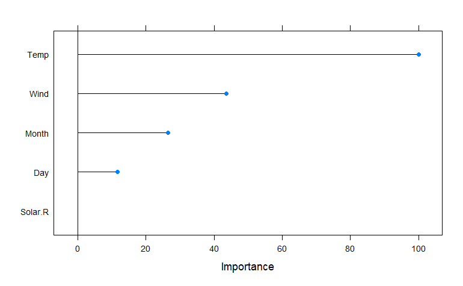

```r
plot(varImp(fit.lm))
```

So we take these variables for further improvement.

```r
fit.lm1 <- train(Ozone~Wind+Temp+Month+Day, data=training, method="lm", metric="Rsquared")

summary(fit.lm1)
```

```
Call:
lm(formula = .outcome ~ ., data = dat)

Residuals:
   Min     1Q Median     3Q    Max
-40.25 -10.26  -1.17  10.48  47.78

Coefficients:
            Estimate Std. Error t value Pr(>|t|)
(Intercept) -66.0009    18.0799  -3.651 0.000417 ***
Wind         -2.5574     0.5561  -4.599 1.23e-05 ***
Temp          2.0210     0.1999  10.112  < 2e-16 ***
Month        -4.5180     1.2060  -3.746 0.000299 ***
Day           0.3577     0.1796   1.992 0.049113 *
---
Signif. codes:  0 ‘***’ 0.001 ‘**’ 0.01 ‘*’ 0.05 ‘.’ 0.1 ‘ ’ 1

Residual standard error: 16.27 on 101 degrees of freedom
Multiple R-squared:  0.6571,    Adjusted R-squared:  0.6435
F-statistic: 48.39 on 4 and 101 DF,  p-value: < 2.2e-16
```

### Check the prediction Quality

Make predictions on unseen data

```r
predictions<-predict(fit.lm1, testing)
```

Check the distribution of the residuals

```r
# density plot of residuals
residuals <- testing$Ozone - predictions
```

Now we want to see how the model behaves with our testing data. And it shows no normal distribution. Again, more a skewed distribution.

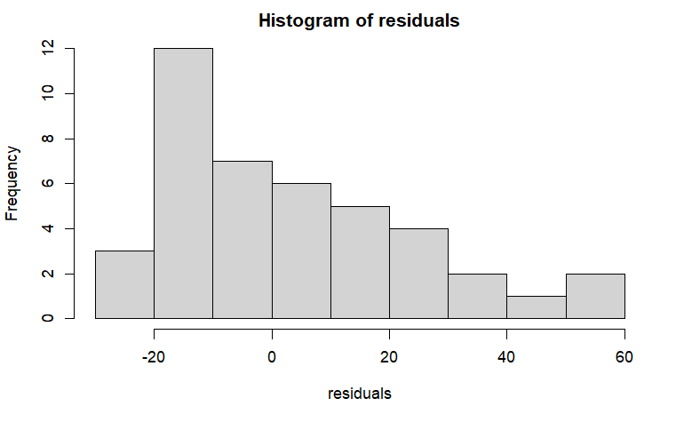

```r
hist(residuals)
```

Coefficient of determination

```r
SSE <- sum(residuals^2)
SST <- sum((testing$Ozone-mean(testing$Ozone))^2)
Rsq <-1-SSE/SST
Rsq
```

```
[1] 0.6087311
```

But we see a higher Rsquared coeff. with the non normalized data.

### Exponential Transformation

Now we will try a exponential approach on our data

```r
fit.lm2 <- train(Ozone~exp(Wind)+exp(Temp)+exp(Month)+exp(Day), data=training, method="lm", metric="Rsquared")

summary(fit.lm2)
```

```
Call:
lm(formula = .outcome ~ ., data = dat)

Residuals:
   Min     1Q Median     3Q    Max
-40.56 -22.12  -4.39  16.18  65.14

Coefficients:
               Estimate Std. Error t value Pr(>|t|)
(Intercept)   4.386e+01  3.464e+00  12.664   <2e-16 ***
`exp(Wind)`  -2.343e-06  9.925e-07  -2.360   0.0202 *
`exp(Temp)`   3.228e-41  1.831e-41   1.763   0.0810 .
`exp(Month)` -9.851e-04  8.398e-04  -1.173   0.2435
`exp(Day)`    1.165e-12  5.728e-13   2.034   0.0446 *
---
Signif. codes:  0 ‘***’ 0.001 ‘**’ 0.01 ‘*’ 0.05 ‘.’ 0.1 ‘ ’ 1

Residual standard error: 25.73 on 101 degrees of freedom
Multiple R-squared:  0.1429,    Adjusted R-squared:  0.1089
F-statistic: 4.209 on 4 and 101 DF,  p-value: 0.003417
```

Here we see our model behaving much worse with the exp() transformation.

### Check the prediction Quality

Make predictions on unseen data

```r
predictions<-predict(fit.lm2, testing)
```

Check the distribution of the residuals

```r
# density plot of residuals
residuals <- testing$Ozone - predictions
```

```r
hist(residuals)
```

[output not shown]

Coefficient of determination

```r
SSE <- sum(residuals^2)
SST <- sum((testing$Ozone-mean(testing$Ozone))^2)
Rsq <-1-SSE/SST
Rsq
```

```
[1] 0.05582922
```

But we see a much fewer Rsquared coeff. with using the exp() transformation on the non normalized data.

### End Summary:

Its obvious in my case that the best Rsquared coeff. of 0.60 can be achieved using the PMM number 1 instead of 2 and not normalized data. Especially the transformation exp() did harm my coeff.